# Exercise Solution

| # Visualising the Spatial Distirbution of MSOA Accessibility to Green Space |
| --- |
| Geospatial-statistical analysis of MSOA accessibility to publicly accessible green spaces in Greater London. |

## National Statistics Postcode Lookup

- The [National Statistics Postcode Lookup (NSPL)](https://www.ons.gov.uk/methodology/geography/geographicalproducts/postcodeproducts) can be used to allocate your source statistics at postcode-level to a wide range of higher UK statistical and administrative geographies.
- The NSPL does the by allocating UK postcodes to Output Areas (OA). These OAs are then referenced to a wide range of higher statistical geographies (for example, local authority districts [LADs]) by a best-fit methodology that uses Census population data.
- The postcode centroid point geometry provides the 1-meter grid reference location (x, y) of the mean address in the postcode snapped to the nearest property.
- We’ll use the NSPL for postcode centroid point geometries and for the references to Middle Layer Super Output Area (MSOA) and Regions.

## OS Open Greenspace

The OS OpenData product [OS Open Greenspace](https://www.ordnancesurvey.co.uk/business-government/products/open-map-greenspace) depicts the location and extent of spaces such as parks and sports facilities that are likely to be accessible to the public. Where appropriate, it also includes Access Points to show how people get into these sites. Its primary purpose is to enable members of the public to find and access greenspaces near them for exercise and recreation.

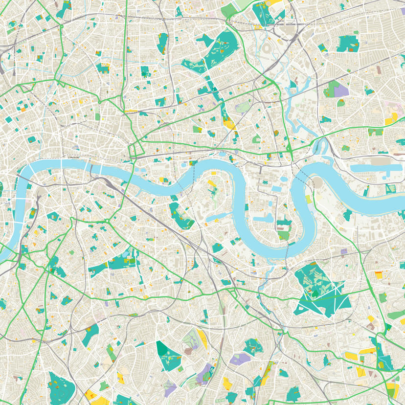

Example of the OS Open Greenspace product.

## Middle Layer Super Output Areas

```r
library(sf)
library(httr)
library(jsonlite)
library(tmap)
library(dplyr)
library(ggplot2)
```

## NSPL

1. Read the NSPL CSV data into a data frame.
2. Return the head of the data frame
3. List all columns of the data frame.
4. Count the rows.
5. Subset the data frame only keeping live postcodes (`doterm` is `NULL`) referencing the Greater London region (`rgn` equal to `E12000007`).
6. Rename the following columns: `oseast1m` to `x`, `osnrth1m` to `y`, `msoa11` to `msoa11cd` and `rgn` to `rgn20cd`.
7. Count the rows in the subset.
8. Construct an `sf` object from the data frame with the geometry column representing a point type constructed from the postcode centroid x and y coordinates.
9. Assign the data frame CRS to British National Grid (EPSG:27700).
10. Return the CRS assignment.
11. Count rows by geometry type.
12. Check geometry validity.
13. Create a static plot of the subset `sf` object. Use a qualitative colour hex value from the GDV toolkit and reduce the marker size and marker transparency to create a dot-density map.

```r
# Read the NSPL CSV data into a data frame
nspl <- read.csv('../../data/office-for-national-statistics/nspl-feb-2023-uk.csv')

# Return the head of the data.frame
head(nspl)
```

|  | pcd | pcd2 | pcds | dointr | doterm | usertype | oseast1m | osnrth1m | osgrdind | oa11 | cty | ced | laua | ward | hlthau | nhser | ctry | rgn | pcon | eer | teclec | ttwa | pct | itl | park | lsoa11 | msoa11 | wz11 | ccg | … |
| --- | --- | --- | --- | --- | --- | --- | --- | --- | --- | --- | --- | --- | --- | --- | --- | --- | --- | --- | --- | --- | --- | --- | --- | --- | --- | --- | --- | --- | --- | --- |
| 1 | BR1 1AA | BR1 1AA | BR1 1AA | 201605 | NA | 0 | 540291 | 168873 | 1 | E00003264 | E13000002 | E99999999 | E09000006 | E05000109 | E18000007 | E40000003 | E92000001 | E12000007 | E14000604 | E15000007 | E24000016 | E30000234 | E16000004 | E09000006 | E99999999 | E01000675 | E02000144 | E33032832 | E38000244 | … |
| 2 | BR1 1AB | BR1 1AB | BR1 1AB | 201203 | NA | 0 | 540262 | 169405 | 1 | E00003255 | E13000002 | E99999999 | E09000006 | E05000109 | E18000007 | E40000003 | E92000001 | E12000007 | E14000604 | E15000007 | E24000016 | E30000234 | E16000004 | E09000006 | E99999999 | E01000676 | E02000134 | E33029192 | E38000244 | … |
| 3 | BR1 1AD | BR1 1AD | BR1 1AD | 201409 | 201709 | 1 | 540386 | 168710 | 1 | E00003264 | E13000002 | E99999999 | E09000006 | E05000109 | E18000007 | E40000003 | E92000001 | E12000007 | E14000604 | E15000007 | E24000016 | E30000234 | E16000004 | E09000006 | E99999999 | E01000675 | E02000144 | E33029199 | E38000244 | … |
| 4 | BR1 1AE | BR1 1AE | BR1 1AE | 200808 | NA | 0 | 540197 | 169204 | 1 | E00003266 | E13000002 | E99999999 | E09000006 | E05000109 | E18000007 | E40000003 | E92000001 | E12000007 | E14000604 | E15000007 | E24000016 | E30000234 | E16000004 | E09000006 | E99999999 | E01000677 | E02000144 | E33029200 | E38000244 | … |
| 5 | BR1 1AF | BR1 1AF | BR1 1AF | 201505 | NA | 0 | 540259 | 168855 | 1 | E00003264 | E13000002 | E99999999 | E09000006 | E05000109 | E18000007 | E40000003 | E92000001 | E12000007 | E14000604 | E15000007 | E24000016 | E30000234 | E16000004 | E09000006 | E99999999 | E01000675 | E02000144 | E33032832 | E38000244 | … |
| 6 | BR1 1AG | BR1 1AG | BR1 1AG | 201509 | NA | 0 | 540259 | 168855 | 1 | E00003264 | E13000002 | E99999999 | E09000006 | E05000109 | E18000007 | E40000003 | E92000001 | E12000007 | E14000604 | E15000007 | E24000016 | E30000234 | E16000004 | E09000006 | E99999999 | E01000675 | E02000144 | E33032832 | E38000244 | … |

```r
# List all columns of the data frame
names(nspl)
```

```
 [1] "pcd"      "pcd2"     "pcds"     "dointr"   "doterm"   "usertype" "oseast1m" "osnrth1m" "osgrdind"
[10] "oa11"     "cty"      "ced"      "laua"     "ward"     "hlthau"   "nhser"    "ctry"     "rgn"
[19] "pcon"     "eer"      "teclec"   "ttwa"     "pct"      "itl"      "park"     "lsoa11"   "msoa11"
[28] "wz11"     "ccg"      "bua11"    "buasd11"  "ru11ind"  "oac11"    "lat"      "long"     "lep1"
[37] "lep2"     "pfa"      "imd"      "calncv"   "stp"
```

```r
# Count the rows
nrow(nspl)
```

```
[1] 327958
```

```r
# Subset the data frame only keeping live postcodes
nspl <- nspl[is.na(nspl$doterm) &  # Live postcodes have a NA termination date in the 'doterm' column
               nspl$rgn == 'E12000007',  # Already subset to the Greater London Region (GSS code equal to 'E12000007')
             c('pcds', 'oseast1m', 'osnrth1m', 'msoa11', 'rgn')]
```

```r
# Rename columns
names(nspl) <- replace(setNames(nm = names(nspl)),
                       c('oseast1m', 'osnrth1m', 'msoa11', 'rgn'),  # Original names
                       c('x', 'y', 'msoa11cd', 'rgn20cd'))  # Modified names
```

```r
# Count the rows in the subset
nrow(nspl)
```

```
[1] 180528
```

```r
# Construct an sf object from the data frame.
# The geometry column is a point type constructed from the postcode centroid x and y
nspl_gdf <- st_as_sf(nspl,
                     coords = c('x', 'y'),  # Specify the columns with coordinates
                     crs = 27700)  # Set CRS to BNG (EPSG:27700)
```

```r
# Return the CRS assignment
st_crs(nspl_gdf)
```

```
Coordinate Reference System:
  User input: EPSG:27700
  wkt:
PROJCRS["OSGB 1936 / British National Grid",
    BASEGEOGCRS["OSGB 1936",
        DATUM["OSGB 1936",
            ELLIPSOID["Airy 1830",6377563.396,299.3249646,
                LENGTHUNIT["metre",1]]],
        PRIMEM["Greenwich",0,
            ANGLEUNIT["degree",0.0174532925199433]],
        ID["EPSG",4277]],
    CONVERSION["British National Grid",
        METHOD["Transverse Mercator",
            ID["EPSG",9807]],
        PARAMETER["Latitude of natural origin",49,
            ANGLEUNIT["degree",0.0174532925199433],
            ID["EPSG",8801]],
        PARAMETER["Longitude of natural origin",-2,
            ANGLEUNIT["degree",0.0174532925199433],
            ID["EPSG",8802]],
        PARAMETER["Scale factor at natural origin",0.9996012717,
            SCALEUNIT["unity",1],
            ID["EPSG",8805]],
        PARAMETER["False easting",400000,
            LENGTHUNIT["metre",1],
            ID["EPSG",8806]],
        PARAMETER["False northing",-100000,
            LENGTHUNIT["metre",1],
            ID["EPSG",8807]]],
    CS[Cartesian,2],
        AXIS["(E)",east,
            ORDER[1],
            LENGTHUNIT["metre",1]],
        AXIS["(N)",north,
            ORDER[2],
            LENGTHUNIT["metre",1]],
    USAGE[
        SCOPE["unknown"],
        AREA["UK - Britain and UKCS 49°46'N to 61°01'N, 7°33'W to 3°33'E"],
        BBOX[49.75,-9.2,61.14,2.88]],
    ID["EPSG",27700]]
```

```r
# Count row by geometry type
table(st_geometry_type(nspl_gdf))
```

```
          GEOMETRY              POINT         LINESTRING            POLYGON         MULTIPOINT
                 0             180528                  0                  0                  0
   MULTILINESTRING       MULTIPOLYGON GEOMETRYCOLLECTION     CIRCULARSTRING      COMPOUNDCURVE
                 0                  0                  0                  0                  0
      CURVEPOLYGON         MULTICURVE       MULTISURFACE              CURVE            SURFACE
                 0                  0                  0                  0                  0
 POLYHEDRALSURFACE                TIN           TRIANGLE
                 0                  0                  0
```

```r
# Check geometry validity
table(st_is_valid(nspl_gdf))
```

```
  TRUE
180528
```

```r
# Create a static plot of the subset data frame
tmap_mode('plot')
```

```
tmap mode set to plotting
```

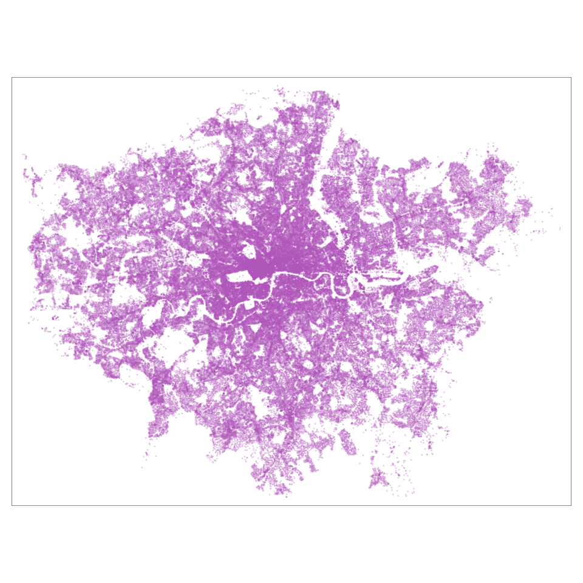

```r
nspl_plot <- tm_shape(nspl_gdf) +
              tm_dots(col = '#af58ba', alpha = 0.2)

nspl_plot
```

## OS Open Greenspace

1. Read the `greenspace_site` layer from the GPKG dataset into an `sf` data frame.
2. Subset columns (keeping only `id`, `function` and `geometry`) and filter for green space function `Public Park Or Garden` or `Playing Field`.
3. Return the head of the data frame
4. Count the rows.
5. Count rows by geometry type.
6. Check geometry validity.
7. Create a static plot of the centroid of each MultiPolygon geometry. Use a qualitative colour hex value from the GDV toolkit.

```r
# Read the GreenspaceSite layer from the GPKG dataset
osogs <- st_read('../../data/ordnance-survey/os-open-greenspace-gb.gpkg',
                 layer = 'greenspace_site')  # Specify the GPKG feature table / layer
# Subset columns and filter for green space function 'Public Park Or Garden' or 'Playing Field'
osogs <- osogs[osogs$function. %in% c('Public Park Or Garden', 'Playing Field'),
               c('id', 'function.', 'geometry')]

# Return the head of the data frame
head(osogs)
```

```
Simple feature collection with 6 features and 2 fields
Geometry type: MULTIPOLYGON
Dimension:     XY
Bounding box:  xmin: 254567.6 ymin: 698166.2 xmax: 386641.4 ymax: 868379.2
Projected CRS: OSGB 1936 / British National Grid
                                     id     function.                       geometry
4  F340858A-BBEB-7DA2-E053-AAEFA00AB6EA Playing Field MULTIPOLYGON (((349314.7 86...
13 F34085DC-F59A-7DA2-E053-AAEFA00AB6EA Playing Field MULTIPOLYGON (((386592.5 80...
19 F340858F-257E-7DA2-E053-AAEFA00AB6EA Playing Field MULTIPOLYGON (((254573.2 85...
23 F3408708-9FBD-7DA2-E053-AAEFA00AB6EA Playing Field MULTIPOLYGON (((287125.6 72...
27 F3408598-A7B5-7DA2-E053-AAEFA00AB6EA Playing Field MULTIPOLYGON (((301982.1 69...
35 F3408616-0B56-7DA2-E053-AAEFA00AB6EA Playing Field MULTIPOLYGON (((288784.1 85...
```

```r
# Count the rows
nrow(osogs)
```

```
[1] 33467
```

```r
# Count rows by geometry type
table(st_geometry_type(osogs))
```

```
          GEOMETRY              POINT         LINESTRING            POLYGON         MULTIPOINT
                 0                  0                  0                  0                  0
   MULTILINESTRING       MULTIPOLYGON GEOMETRYCOLLECTION     CIRCULARSTRING      COMPOUNDCURVE
                 0              33467                  0                  0                  0
      CURVEPOLYGON         MULTICURVE       MULTISURFACE              CURVE            SURFACE
                 0                  0                  0                  0                  0
 POLYHEDRALSURFACE                TIN           TRIANGLE
                 0                  0                  0
```

```r
# Check geometry validity
table(st_is_valid(osogs))
```

```
 TRUE
33467
```

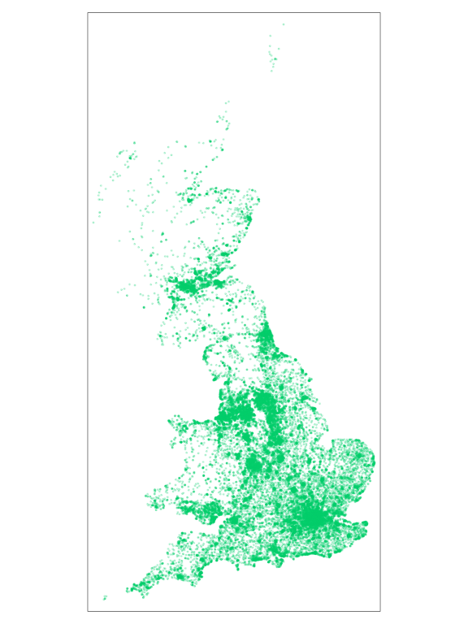

```r
# Create a static plot of the centroid of each MultiPolygon geoemtry
# Follow GDV best practice
osogs_plot <- tm_shape(st_centroid(osogs)) +
                tm_dots(col = '#00cd6c', alpha = 0.2)
osogs_plot
```

## Spatially join the NSPL and OS Open Greenspace

```r
# Spatially join the rows within the nspl and osogs data.frames

# Find nearest green space
nearId <- st_nearest_feature(nspl_gdf, osogs)
# This returns a vector with a row ID in `osogs` for each NSPL record

# Join the two data frames by expansion
nspl2osogs <- cbind(nspl_gdf, osogs[nearId, ])

# Examine this new data.frame
head(nspl2osogs)
```

```
Simple feature collection with 6 features and 5 fields
Active geometry column: geometry
Geometry type: POINT
Dimension:     XY
Bounding box:  xmin: 540197 ymin: 168754 xmax: 540430 ymax: 169405
Projected CRS: OSGB 1936 / British National Grid
     pcds  msoa11cd   rgn20cd                                   id             function.
1 BR1 1AA E02000144 E12000007 F3408626-F2D5-7DA2-E053-AAEFA00AB6EA Public Park Or Garden
2 BR1 1AB E02000134 E12000007 F3408626-F2D5-7DA2-E053-AAEFA00AB6EA Public Park Or Garden
4 BR1 1AE E02000144 E12000007 F3408626-F2D5-7DA2-E053-AAEFA00AB6EA Public Park Or Garden
5 BR1 1AF E02000144 E12000007 F3408626-F2D5-7DA2-E053-AAEFA00AB6EA Public Park Or Garden
6 BR1 1AG E02000144 E12000007 F3408626-F2D5-7DA2-E053-AAEFA00AB6EA Public Park Or Garden
7 BR1 1AH E02000144 E12000007 F3408626-F2D5-7DA2-E053-AAEFA00AB6EA Public Park Or Garden
               geometry                     geometry.1
1 POINT (540291 168873) MULTIPOLYGON (((540122.6 16...
2 POINT (540262 169405) MULTIPOLYGON (((540122.6 16...
4 POINT (540197 169204) MULTIPOLYGON (((540122.6 16...
5 POINT (540259 168855) MULTIPOLYGON (((540122.6 16...
6 POINT (540259 168855) MULTIPOLYGON (((540122.6 16...
7 POINT (540430 168754) MULTIPOLYGON (((540122.6 16...
```

```r
# Calculate the distance between each pair: NSPL -- green space
nspl2osogs$distance <- st_distance(nspl2osogs$geometry,
                                   nspl2osogs$geometry.1,
                                   by_element = TRUE)
# Remove 'units'
nspl2osogs$distance <- as.numeric(nspl2osogs$distance)

# Drop the green space geometry (no longer needed)
nspl2osogs$geometry.1 <- NULL
```

```r
# Count the rows
nrow(nspl2osogs)
```

```
[1] 180528
```

```r
# Count the number of unique postcodes
length(unique(nspl2osogs$pcds))
```

```
[1] 180528
```

```r
# Check that the number of unique postcodes is equal to the postcodes in the
# Greater London subset of the NSPL
length(unique(nspl2osogs$pcds)) == length(unique(nspl_gdf$pcds))
```

```
[1] TRUE
```

```r
# Calculate the mean distance to a green space per MSOA
# Do this by grouping by the msoa11cd of the distance
msoa_mean <- aggregate(list('distance' = nspl2osogs$distance),
                       by = list('msoa11cd' = nspl2osogs$msoa11cd),
                       mean)

# Return the head of the data frame
head(msoa_mean)
```

|  | msoa11cd | distance |
| --- | --- | --- |
| 1 | E02000001 | 224.5577 |
| 2 | E02000002 | 270.3922 |
| 3 | E02000003 | 297.1523 |
| 4 | E02000004 | 162.5388 |
| 5 | E02000005 | 316.6833 |
| 6 | E02000007 | 216.5037 |

```r
# Return data frame descriptive statistics
summary(msoa_mean)
```

```
   msoa11cd            distance
 Length:983         Min.   : 79.3
 Class :character   1st Qu.:193.9
 Mode  :character   Median :252.8
                    Mean   :269.5
                    3rd Qu.:325.7
                    Max.   :623.8
```

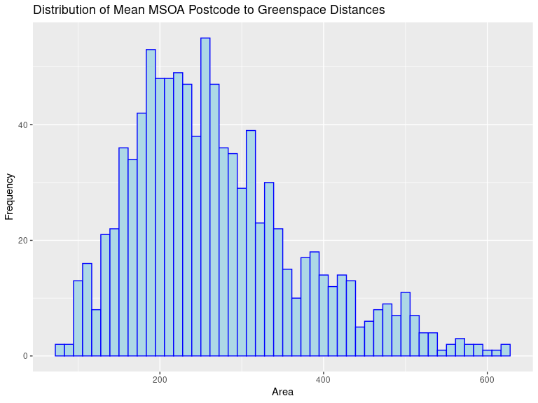

```r
# Plot a MSOA-mean distance histogram
ggplot(msoa_mean, aes(x = distance)) +
  geom_histogram(bins = 50,
                 fill = 'lightblue',
                 color = 'blue') +
  xlab('Area') +
  ylab('Frequency') +
  ggtitle('Distribution of Mean MSOA Postcode to Greenspace Distances')
```

```r
# Populate a new #rank' column binning each MSOA into one of seven classes
# ordering by the mean distance.
# Specify rank labels 1-7.

# Get quantile break points for seven groups
qdist <- quantile(msoa_mean$distance,
                  probs = (0:7) / 7)

# Populate rank column
msoa_mean$rank <- cut(msoa_mean$distance,
                      breaks = qdist,
                      labels = 1:7,
                      include.lowest = TRUE)

# Return head of data frame
head(msoa_mean)
```

|  | msoa11cd | distance | rank |
| --- | --- | --- | --- |
| 1 | E02000001 | 224.5577 | 3 |
| 2 | E02000002 | 270.3922 | 5 |
| 3 | E02000003 | 297.1523 | 5 |
| 4 | E02000004 | 162.5388 | 1 |
| 5 | E02000005 | 316.6833 | 6 |
| 6 | E02000007 | 216.5037 | 3 |

```r
# Count the rows
nrow(msoa_mean)
```

```
[1] 983
```

```r
# Check that the number of MSOAs is equal to the number of unique MSOAs in
# Greater London in the subset of the NSPL
nrow(msoa_mean) == length(unique(nspl$msoa11cd))
```

```
[1] TRUE
```

## MSOA Boundaries

1. Read the MSOA GeoPackage (GPKG) dataset into an `sf` data frame.
2. Return the head of the data frame.
3. Count the rows.
4. Subset the columns keeping only `MSOA11CD` and `SHAPE`.
5. Rename `MSOA11CD` column to `msoa11cd`.
6. Count rows by geometry type.
7. Check geometry validity.
8. Inner join (by attribute) the rows within this `msoa` data frame and the `msoa_mean` data frame on the `msoa11cd` column.
9. Return the head of the data frame.
10. Count the rows.

```r
# Read GPKG into an `sf` data.frame.
msoa <- st_read('../../data/office-for-national-statistics/msoa-dec-2011-boundaries-bfc-ew.gpkg')
# Return the head of the data.frame
head(msoa)
```

```
Simple feature collection with 6 features and 8 fields
Geometry type: MULTIPOLYGON
Dimension:     XY
Bounding box:  xmin: 530966.7 ymin: 180510.7 xmax: 551943.8 ymax: 191139
Projected CRS: OSGB 1936 / British National Grid
   MSOA11CD                 MSOA11NM  BNG_E  BNG_N     LONG_     LAT Shape_Leng
1 E02000001       City of London 001 532384 181355 -0.093490 51.5156   9297.652
2 E02000002 Barking and Dagenham 001 548267 189685  0.138756 51.5865   8306.888
3 E02000003 Barking and Dagenham 002 548259 188520  0.138149 51.5760   9359.512
4 E02000004 Barking and Dagenham 003 551004 186412  0.176828 51.5564   8475.840
5 E02000005 Barking and Dagenham 004 548733 186824  0.144267 51.5607   7321.657
6 E02000007 Barking and Dagenham 006 549698 186609  0.158087 51.5585   7070.107
                                GlobalID                          SHAPE
1 {8717BEE3-697E-4EFD-ABF7-F217233C83CF} MULTIPOLYGON (((532153.7 18...
2 {77860E2F-F7C0-429E-8CFE-C769A3CF7213} MULTIPOLYGON (((548881.3 19...
3 {66B060CC-DE1C-446C-BFDE-4AD443182D70} MULTIPOLYGON (((548958.6 18...
4 {A94A3CFA-F35D-4191-BC60-7E56A009A421} MULTIPOLYGON (((551550.1 18...
5 {23CEC695-5AC4-4144-B4E4-611BCBB99AC9} MULTIPOLYGON (((549237.1 18...
6 {F556290A-3765-4205-BBE8-1BA5ABFB5E59} MULTIPOLYGON (((549669.6 18...
```

```r
# Count the rows
nrow(msoa)
```

```
[1] 7201
```

```r
# Subset the columns
msoa <- msoa[, c('MSOA11CD', 'SHAPE')]
```

```r
# Rename the columns
names(msoa)[1] <- 'msoa11cd'
# If you try to rename the geometry column, need to use `st_geometry(x)<-`
```

```r
# Count the rows by geometry type
table(st_geometry_type(msoa))
```

```
          GEOMETRY              POINT         LINESTRING            POLYGON         MULTIPOINT
                 0                  0                  0                  0                  0
   MULTILINESTRING       MULTIPOLYGON GEOMETRYCOLLECTION     CIRCULARSTRING      COMPOUNDCURVE
                 0               7201                  0                  0                  0
      CURVEPOLYGON         MULTICURVE       MULTISURFACE              CURVE            SURFACE
                 0                  0                  0                  0                  0
 POLYHEDRALSURFACE                TIN           TRIANGLE
                 0                  0                  0
```

```r
# Check geometry validity
table(st_is_valid(msoa))
```

```
TRUE
7201
```

```r
# Inner join (by attribute) the rows within the msoa data frame and the
# msoa_mean data frame on the `msoa11cd` column
msoa_mean_gdf <- merge(msoa,
                       msoa_mean,
                       by = 'msoa11cd',
                       all.x = FALSE)  # creates an inner join

# Return the head of the data frame
head(msoa_mean_gdf)
```

```
Simple feature collection with 6 features and 3 fields
Geometry type: MULTIPOLYGON
Dimension:     XY
Bounding box:  xmin: 530966.7 ymin: 180510.7 xmax: 551943.8 ymax: 191139
Projected CRS: OSGB 1936 / British National Grid
   msoa11cd distance rank                       geometry
1 E02000001 224.5577    3 MULTIPOLYGON (((532153.7 18...
2 E02000002 270.3922    5 MULTIPOLYGON (((548881.3 19...
3 E02000003 297.1523    5 MULTIPOLYGON (((548958.6 18...
4 E02000004 162.5388    1 MULTIPOLYGON (((551550.1 18...
5 E02000005 316.6833    6 MULTIPOLYGON (((549237.1 18...
6 E02000007 216.5037    3 MULTIPOLYGON (((549669.6 18...
```

```r
# Count the rows
nrow(msoa_mean_gdf)
```

```
[1] 983
```

## OS GeoDataViz Sequential Palette

1. Download and decode the JSON representations of the OS [GDV colour palettes](https://raw.githubusercontent.com/OrdnanceSurvey/GeoDataViz-Toolkit/master/Colours/GDV-colour-palettes-v0.7.json) via an HTTP GET request.
2. Access the `m2` colour palette within the `sequential` palette group.
3. Return and display the colour map.

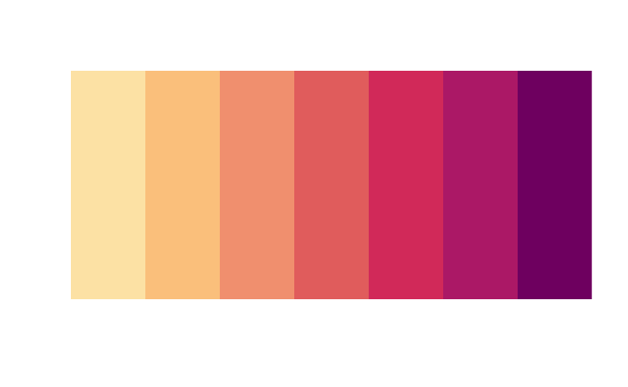

```r
# Download and decode the JSON representation of the OS GDV colour palettes via
# an HTTP GET request
gdv <- 'https://raw.githubusercontent.com/OrdnanceSurvey/GeoDataViz-Toolkit/master/Colours/GDV-colour-palettes-v0.7.json'

# Make HTTP GET request and decode JSON
gdv_json <- GET(url = gdv)
gdv_json <- fromJSON(content(gdv_json))

# Get colour hex values
gdv_cmap <- gdv_json$sequential$m2

# Show an example of the colours
(image(1:length(gdv_cmap), 1, as.matrix(1:length(gdv_cmap)),
      col = gdv_cmap,
      xlab="", ylab = "", xaxt = "n", yaxt = "n", bty = "n"))
```

### Static Map

1. Create a static plot overlaying the centroids of the `osogs` spatial data frame, within the Greater London bounding region, on top of a choropleth map showing MSOA mean distance to green space, from the `msoa_mean_gdf` spatial data frame. The map should be styled using GDV best practice and the mean distance coloured using the `m2` GDV colour map against the `rank` bin column.

```r
# Store a plot of the msoa_mean_gdf data frame
msoa_plot <- tm_shape(msoa_mean_gdf) +
                tm_polygons(col = 'rank',  # column name
                            palette = gdv_cmap,  # colour palette
                            style = 'cat')  # use a categorical classification
```

```r
# Clip the osogs data frame to the bounding box of Greater London
bbox <- st_as_sfc(st_bbox(msoa_mean_gdf), crs = 27700)

# Filter green space based on intersecting features
osogs <- osogs[bbox, ]
```

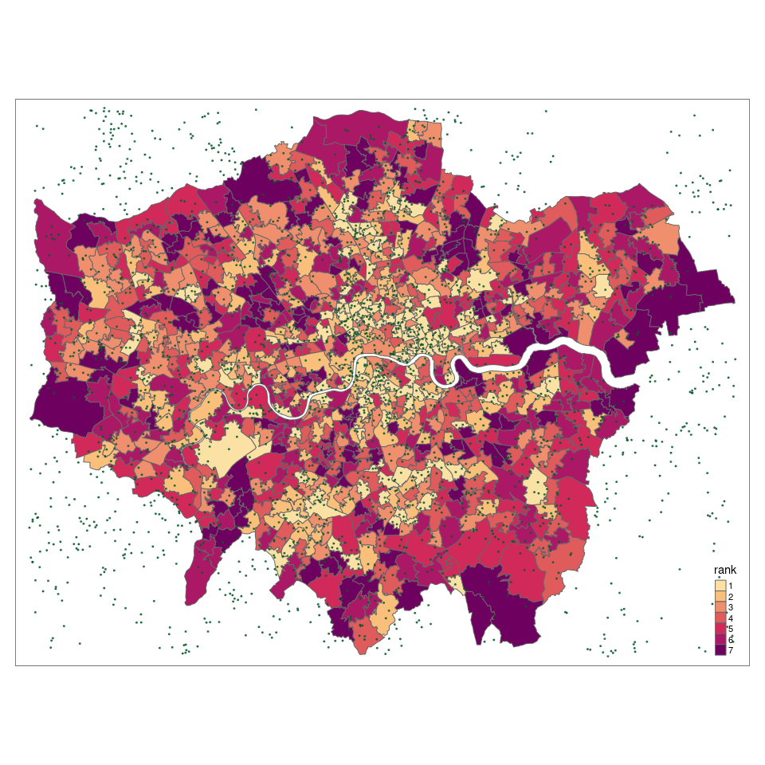

```r
# Plot the centroid of each geometry in the osogs data frame and add to the msoa
# plot
final_plot <- msoa_plot +
                tm_shape(st_centroid(osogs)) +
                tm_dots(col = '#06592a', alpha = 0.75)
final_plot
```

### Interactive Map

1. Create an interactive map using `tmap` (set `tmap_mode('view')`) showing MSOA mean distance to green space, from the `msoa_mean_gdf` data frame. The map should be styped using GDV best practices and the mean distance coloured using the `m2` GDV colour map against the `rank` bin column. The map should use an OS Maps API Light Style 3857 base map.
- Note: This step can use the `msoa_plot` as an overlay to a basemap.

```r
# OS Maps API layer
# Example uses Light Style in Web Mercator (EPSG:3857) projection
layer <- 'Light_3857'

# OS Data Hub project API key
key <- '7UTXMMWsGjjIzcBmLdAGnMO6WEAQi9Ng'
```

```r
# Define the tile server parameters for the basemap
url <- paste0('https://api.os.uk/maps/raster/v1/zxy/', layer,
              '/{z}/{x}/{y}.png?key=', key)
```

```r
# Create the interactive map the OS Maps API base map
tmap_mode('view')
```

```
tmap mode set to interactive viewing
```

```r
m <- msoa_plot +  # starting with the previous map layer
      tm_basemap(server = url)

# m
```

```r
# Return setting to static plot mode.
tmap_mode('plot')
```

```
tmap mode set to plotting
```

## Extension: Quantifying accessibility via a different metric

Finding the distance to each postcode’s nearest green space isn’t the only way to quantify accessibility to green space. Considering that the area (utility) of a green space site may be an important factor in conjunction with distance, one alternative could be to measure the total area of green space within a certain distance of each postcode.

1. Create a new data frame by buffering the NSPL postcode POINT geometries in the `nspl_gdf` data.frame by a threshold distance.
2. Add a new column to the data frame representing the area of the new POLYGON geometry for each postcode.
3. Return the head of the data frame.

```r
# Distance (buffer) threshold in metres
distance_threshold <- 500

# Buffer the postcode POINT geometries by the threshold distance.
# This transforms the geometry type from POINT --> POLYGON
pcds_buffer <- st_buffer(nspl_gdf, dist = distance_threshold)

# Add a new column representing the area of the new POLYGON geometry for each
# postcode.
pcds_buffer$threshold_area <- st_area(pcds_buffer)

# Return the head of the data frame
head(pcds_buffer)
```

```
Simple feature collection with 6 features and 4 fields
Geometry type: POLYGON
Dimension:     XY
Bounding box:  xmin: 539697 ymin: 168254 xmax: 540930 ymax: 169905
Projected CRS: OSGB 1936 / British National Grid
     pcds  msoa11cd   rgn20cd                       geometry threshold_area
1 BR1 1AA E02000144 E12000007 POLYGON ((540791 168873, 54... 785039.3 [m^2]
2 BR1 1AB E02000134 E12000007 POLYGON ((540762 169405, 54... 785039.3 [m^2]
4 BR1 1AE E02000144 E12000007 POLYGON ((540697 169204, 54... 785039.3 [m^2]
5 BR1 1AF E02000144 E12000007 POLYGON ((540759 168855, 54... 785039.3 [m^2]
6 BR1 1AG E02000144 E12000007 POLYGON ((540759 168855, 54... 785039.3 [m^2]
7 BR1 1AH E02000144 E12000007 POLYGON ((540930 168754, 54... 785039.3 [m^2]
```

4. Create a new data frame by evaluating the intersection (shared geometry) between the buffered postcode POLYGON geometries and the OS Open GreenSpace data in the `osog`s data frame.

```r
# Evaluate the intersection (shared geometry) between the buffered postcode
# POLYGON geometries and the OS Open GreenSpace data in the `osogs` data frame.
pcds_buffer_osogs_int <- st_intersection(pcds_buffer, osogs)
```

5. Find the area of overlap.
- Option 1: (Faster)
  - Add a new column to the data frame representing the area of each overlay.
  - Aggregate (sum) the area parts by postcode.
- Option 2: (Slow!)
  - Dissolve (spatially union) the intersection geometries by postcode
  - Add a new column to the data frame representing the area of the intersection geometry by postcode.
6. Return the head of the data frame.

[output not shown]

```r
# Option 2

# Evaluate the intersection (shared geometry) between the buffered postcode
# POLYGON geometries and the OS Open GreenSpace data in the `osogs` data frame.
pcds_buffer_osogs_int <- st_intersection(pcds_buffer, osogs)

# Dissolve (spatially union) the intersection geometries by postcode
# Caution: this step may take some time!
# Note: using `dplyr` tools
pcds_buffer_osogs_int <- group_by(pcds_buffer_osog_int, pcds) %>%
                          summarise()

# Add a new column to the data frame representing the area of the intersection
# geometry by postcode.
pcds_buffer_osogs_int$area <- st_area(pcds_buffer_osog_int)

# Return the head of the data frame (now a tibble)
head(pcds_buffer_osogs_int)
```

[output not shown]

7. A subset of postcodes will not be represented in the data because the buffered POLYGON geometry does not intersect any of the OS Open GreenSpace feature geometries. Add the missing subset of postcodes to the data by merging to the buffered postcode data.
8. Add a new column to the data frame representing a normalised area metric - divide the intersection geometry area by the area of the buffered postcode geometry.
9. Set the normalised area metric to a value of 0 for any missing data.
10. Return the head of the data frame.

```r
# Add the missing subset of postcodes to the data by a left merge
pcds_buffer_osogs_int <- merge(st_drop_geometry(pcds_buffer),  # Exclude geometry
                               pcds_buffer_osogs_int,
                               by = 'pcds',  # Shared column name
                               all.x = TRUE)  # Left join
# Add a new column to the data frame representing a normalised area metric -
# divide the intersection geometry area by the area of the buffered postcode
# geometry.
pcds_buffer_osogs_int$area_normalised <- pcds_buffer_osogs_int$area /
                                          pcds_buffer_osogs_int$threshold_area
# Remove units
pcds_buffer_osogs_int$area_normalised <- as.numeric(pcds_buffer_osogs_int$area_normalised)

# Set the normalised area metric to 0 anywhere the value is missing
pcds_buffer_osogs_int[is.na(pcds_buffer_osogs_int$area_normalised),
                      'area_normalised'] <- 0

# Return the head of the data frame
head(pcds_buffer_osogs_int)
```

|  | pcds | msoa11cd | rgn20cd | threshold_area | area | area_normalised |
| --- | --- | --- | --- | --- | --- | --- |
| 1 | BR1 1AA | E02000144 | E12000007 | 785039.3 [m^2] | 73581.10 [m^2] | 0.09372919 |
| 2 | BR1 1AB | E02000134 | E12000007 | 785039.3 [m^2] | 107296.10 [m^2] | 0.13667608 |
| 3 | BR1 1AE | E02000144 | E12000007 | 785039.3 [m^2] | 138561.33 [m^2] | 0.17650240 |
| 4 | BR1 1AF | E02000144 | E12000007 | 785039.3 [m^2] | 75996.21 [m^2] | 0.09680561 |
| 5 | BR1 1AG | E02000144 | E12000007 | 785039.3 [m^2] | 75996.21 [m^2] | 0.09680561 |
| 6 | BR1 1AH | E02000144 | E12000007 | 785039.3 [m^2] | 43167.01 [m^2] | 0.05498706 |

11. Test whether the number of rows in the NSPL and postcode normalised area datasets are equal.

```r
# Test whether the number of rows in the NSPL and postcode normalised area
# datasets are equal.
nrow(nspl) == nrow(pcds_buffer_osogs_int)
```

```
[1] TRUE
```

12. Plot a histogram of the distribution of postcode normalised area values.

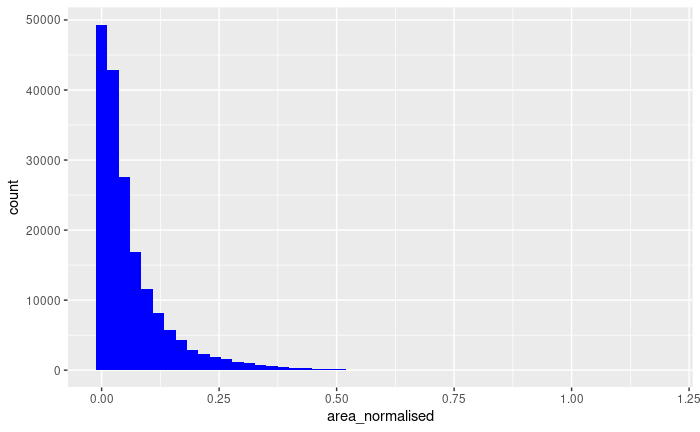

```r
# Plot a histogram of the distribution of postcode normalised area values
# The normalised area metric is very biased towards small values
# Right-skewed (long right tail)
ggplot(pcds_buffer_osogs_int, aes(x = area_normalised)) +
  geom_histogram(fill = 'blue', bins = 50)
```

13. Summarise the postcode normalised area at MSOA-level by calculating the mean area by MSOA.

```r
# Summarise the postcode normalised area at MSOA-level by calculating the mean
# area by MSOA

# Subset the columns
pcds_buffer_osogs_int <- pcds_buffer_osogs_int[, c('msoa11cd', 'area_normalised')]

# Group by msoa11cd key
msoa_area <- aggregate(list('area_normalised' = pcds_buffer_osogs_int$area_normalised),
                       by = list('msoa11cd' = pcds_buffer_osogs_int$msoa11cd),
                       mean)

msoa_area_gdf <- merge(msoa, msoa_area, by = 'msoa11cd')
```

14. Create a static plot representing the spatial distribution in MSOA mean postcode normalised area. Bin the data into seven equal bins and style the classes using a sequential OS GDV colour palette. Overlay the source OS Open GreenSpace MULTIPOLYGON feature data ontop of the thematic map.

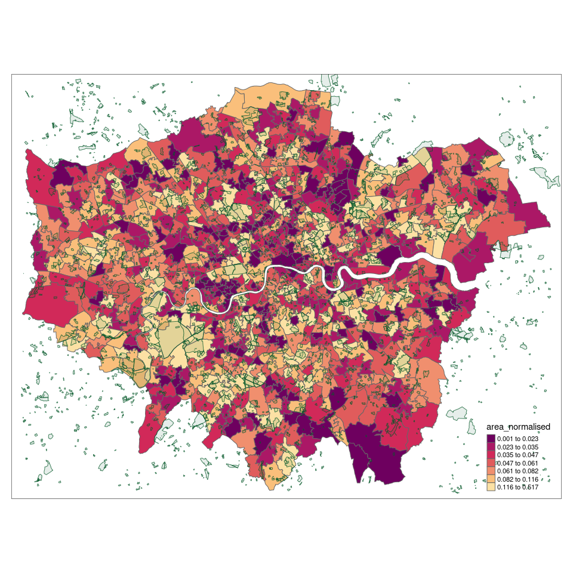

```r
# Plot the MSOA mean, normalised area
msoa_plot <- tm_shape(msoa_area_gdf) +
              tm_polygons(col = 'area_normalised',
                          n = 7,
                          style = 'quantile',
                          palette = rev(gdv_cmap))

# Plot the green space MULTIPOLYGONS
# Transparent faces and less transparent edges
osogs_plot <- tm_shape(osogs) +
                tm_polygons(col = '#06592a', alpha = 0.1,
                            border.col = '#06592a', border.alpha = 0.75)

# Combine plots and display
(msoa_plot + osogs_plot)
```